# Covid-19 In Connecticut and the USA, August 31, 2020

Andrew F. Griffin

8/31/2020

## CONNECTICUT

**NEW REPORTS FOR TODAY, YESTERDAY, LAST WEEK, AND LAST MONTH**

| DATE | STATE | NEW CASES | NEW TESTS | PERCENT POSITIVE | NEW DEATHS |
| --- | --- | --- | --- | --- | --- |
| 2020-08-31 | CT | 384 | 45,590 | 0.8 | 0 |
| 2020-08-30 | CT | 0 | 0 | NaN | 0 |
| 2020-08-24 | CT | 492 | 55,346 | 0.9 | 0 |
| 2020-08-03 | CT | 252 | 35,186 | 0.7 | 5 |

Note:  
Data From the Covid Tracking Project  
Connecticut no longer reports on weekends

**TOTALS PER 100K PEOPLE OVER THE LAST 7 DAYS**

| STATE | SUM NEW CASES PER CAPITA | SUM NEW TESTS PER CAPITA | SUM NEW DEATHS PER CAPITA |
| --- | --- | --- | --- |
| CT | 38.1 | 4219 | 0.14 |

Note:  
Data From the Covid Tracking Project  
Connecticut no longer reports on weekends

As a whole, Connecticut continues to do well, even in the face of cases on the rise in the city of Danbury. For the first time in a while we aren’t in the bottom five of New Case Growth Per Capita over the last seven days, but that is likely due to the fact that a number of states are doing well, and Danbury’s numbers are just enough to throw us off.

Testing remains on it’s upward track, which is very good given the new arrival of students to many of the colleges who are reopening, and our percent positive is remaining low. Again, the big X factor I don’t think is going to be the next couple weeks for students, but rather, the next month or two when things cool off and covid mitigation gets a little laxed when people become more comfortable. Though, my optimisim does still remain.

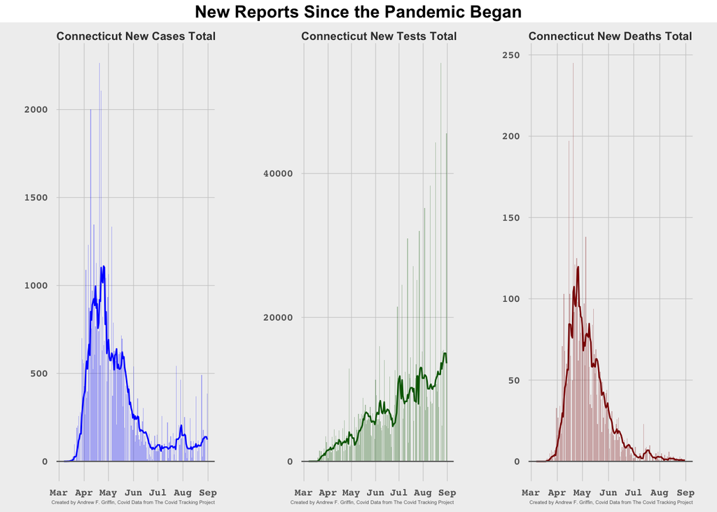

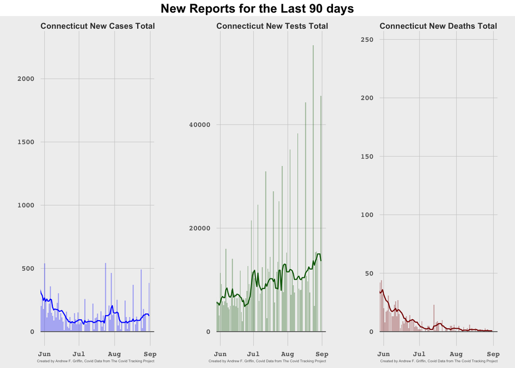

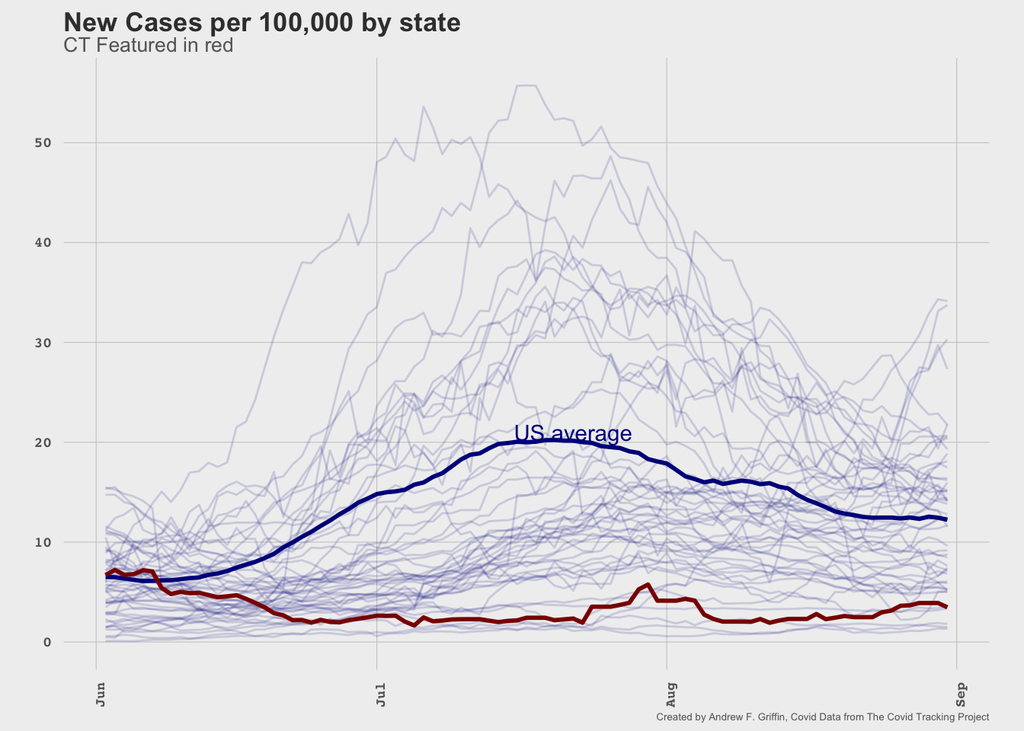

## THE USA

**UNITED STATES TOTAL NEW REPORTS FOR TODAY, YESTERDAY, LAST WEEK, AND LAST MONTH**

| DATE | NEW CASES | NEW TESTS | PERCENT POSITIVE | NEW DEATHS |
| --- | --- | --- | --- | --- |
| 2020-08-31 | 31,353 | 685,072 | 4.6 | 358 |
| 2020-08-30 | 39,487 | 746,269 | 5.3 | 475 |
| 2020-08-24 | 34,530 | 691,236 | 5.0 | 342 |
| 2020-08-03 | 49,749 | 743,916 | 6.7 | 519 |

Note:  
Data From the Covid Tracking Project

**7 DAY UNITED STATES TOTALS**

| TOTAL NEW CASES | TOTAL NEW TESTS | TOTAL NEW DEATHS |
| --- | --- | --- |
| 319,556 | 5,727,892 | 6,781 |

Note:  
Data From the Covid Tracking Project

Watching the US numbers is a little trickier at the moment. New cases had been trending down and now we’re either at a plateau or a just a blip on the way down. Throwing things off are growing cases in North and South Dakotah who now have the #1 and #2 new case per capita growth in the USA and this is very likely due to the Sturgis bike rally. The big question will be if any of those vectors get brought home from other folks to their repective states.

The positive here is, deaths per day is still under a 1,000 in the seven day rolling average, and testing is on the upswing.

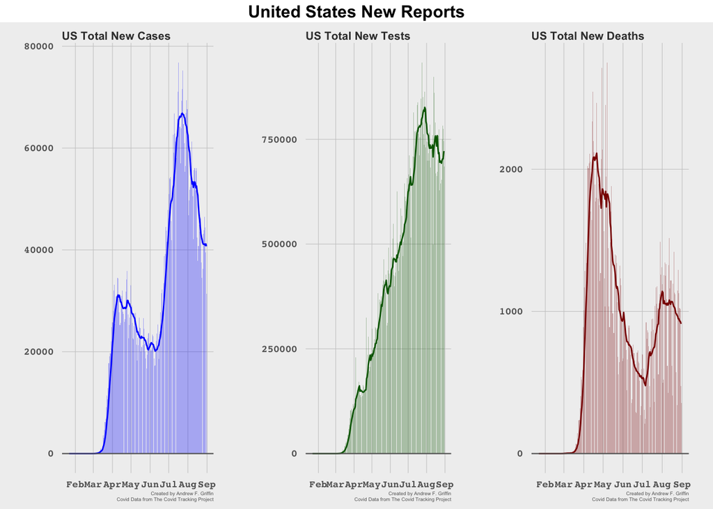

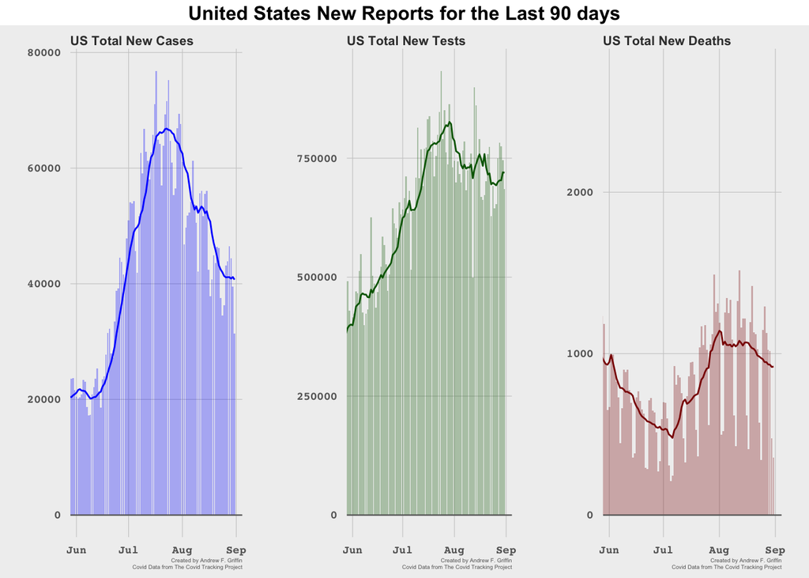

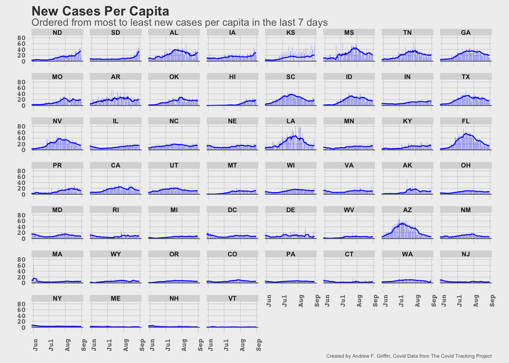

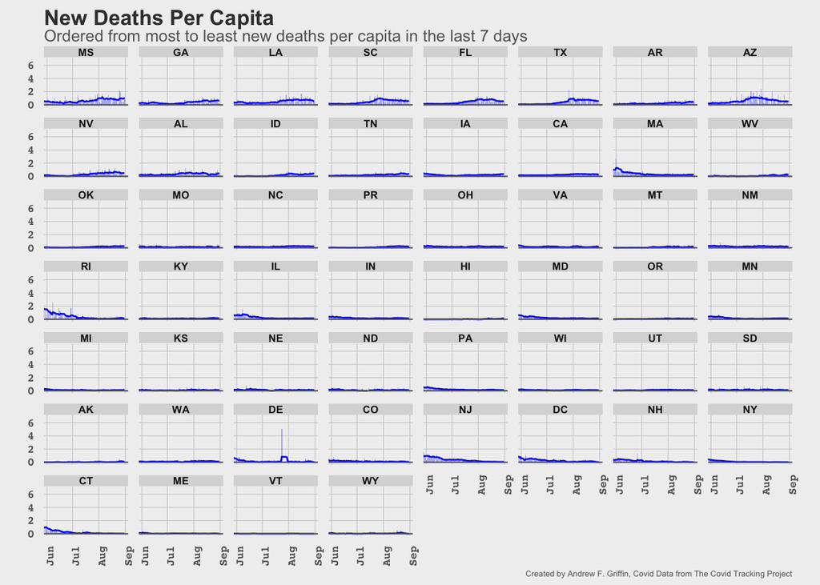